# tidyverse

G. Moroz

### 1. Introduction

[*tidyverse*](https://blog.rstudio.org/2016/09/15/tidyverse-1-0-0/) is a set of packages:

- `dplyr`, for data manipulation
- `ggplot2`, for data visualisation
- `tidyr`, for data tidying
- `readr`, for data import
- `stringr`, for working with strings
- `forcats`, for working with factors
- `purrr`, for functional programming
- `tibble`, for tibbles, a modern re-imagining of data frames

Install `tidyverse` package using `install.packages("tidyverse")`.

```r
library(tidyverse)
theme_set(theme_bw()) # set bright theme
```

### 2. tibble

```r
head(iris)
as_tibble(iris)
tibble(id = 1:12,
           letters = month.name)
```

[output not shown]

### 3. Reading files: `readr`

```r
library(readr) # included in tidyverse
df <- read_csv("https://goo.gl/v7nvho")
head(df)
```

| Gender | Age | AgeGroup | Education | City | SubjectCode | Score | GivenScore | Stimulus | Prefix | WordType | CorpusFrequency |
| --- | --- | --- | --- | --- | --- | --- | --- | --- | --- | --- | --- |
| female | 16 | child | school | Izhevsk | AA | A | 5 | utochnit | u | standard | 2860 |
| female | 16 | child | school | Izhevsk | AA | A | 5 | ozhestochit | o | standard | 686 |
| female | 16 | child | school | Izhevsk | AA | E | 1 | ovneshnit | o | marginal | 4 |
| female | 16 | child | school | Izhevsk | AA | E | 1 | oblusit | o | nonce | 0 |
| female | 16 | child | school | Izhevsk | AA | A | 5 | osvezhit | o | standard | 280 |
| female | 16 | child | school | Izhevsk | AA | A | 5 | oschastlivit | o | standard | 343 |

```r
df <- read_tsv("https://goo.gl/33r2Ut")
head(df)
```

| speaker | year | gender | cons | inn | total |
| --- | --- | --- | --- | --- | --- |
| ait1954 | 1954 | f | 222 | 254 | 476 |
| anp1929 | 1929 | m | 15 | 16 | 31 |
| ans1925 | 1925 | f | 788 | 379 | 1167 |
| avch1930 | 1930 | f | 43 | 6 | 49 |
| avi1958 | 1958 | f | 1 | 31 | 32 |
| avm1922 | 1922 | f | 778 | 235 | 1013 |

```r
df <- read_delim("https://goo.gl/33r2Ut", delim = "\t")
head(df)
```

| speaker | year | gender | cons | inn | total |
| --- | --- | --- | --- | --- | --- |
| ait1954 | 1954 | f | 222 | 254 | 476 |
| anp1929 | 1929 | m | 15 | 16 | 31 |
| ans1925 | 1925 | f | 788 | 379 | 1167 |
| avch1930 | 1930 | f | 43 | 6 | 49 |
| avi1958 | 1958 | f | 1 | 31 | 32 |
| avm1922 | 1922 | f | 778 | 235 | 1013 |

There is also a package `readxl` for reading files from .xls and .xlsx files (even from different sheets).

### 4. `dplyr`

```r
homo <- read_csv("https://raw.githubusercontent.com/LingData2019/LingData/master/data/orientation.csv")
homo
```

| speaker | s.duration.ms | vowel.duration.ms | average.f0.Hz | f0.range.Hz | perceived.as.homo | perceived.as.hetero | perceived.as.homo.percent | orientation | age |
| --- | --- | --- | --- | --- | --- | --- | --- | --- | --- |
| A | 61.40 | 112.60 | 119.51 | 52.5 | 7 | 18 | 0.28 | hetero | 30 |
| B | 63.90 | 126.49 | 100.29 | 114.0 | 20 | 5 | 0.80 | hetero | 19 |
| C | 55.08 | 126.81 | 114.90 | 103.2 | 9 | 16 | 0.36 | homo | 29 |
| D | 78.11 | 119.17 | 126.61 | 58.8 | 15 | 10 | 0.60 | homo | 36 |
| E | 64.71 | 93.68 | 130.76 | 37.4 | 10 | 15 | 0.40 | homo | 27 |
| F | 67.00 | 127.87 | 150.79 | 42.0 | 17 | 8 | 0.68 | homo | 33 |
| G | 65.39 | 147.52 | 128.96 | 118.2 | 20 | 5 | 0.80 | hetero | 28 |
| H | 62.46 | 120.13 | 105.26 | 55.7 | 21 | 4 | 0.84 | hetero | 22 |
| I | 60.45 | 140.44 | 109.86 | 96.4 | 20 | 5 | 0.80 | homo | 22 |
| J | 59.59 | 121.01 | 123.90 | 111.7 | 8 | 17 | 0.32 | homo | 40 |

[output cut: 4 more lines]

The majority of examples in that presentation are based on [Hau 2007](http://goo.gl/MKfSc6). Experiment consisted of a perception and judgment test aimed at measuring the correlation between acoustic cues and perceived sexual orientation. Naïve Cantonese speakers were asked to listen to the Cantonese speech samples collected in Experiment and judge whether the speakers were gay or heterosexual. There are 14 speakers and following parameters:

- [s] duration (*s.duration.ms*)
- vowel duration (*vowel.duration.ms*)
- fundamental frequencies mean (F0) (*average.f0.Hz*)
- fundamental frequencies range (*f0.range.Hz*)
- percentage of homosexual impression (*perceived.as.homo*)
- percentage of heterosexal impression (*perceived.as.hetero*)
- speakers orientation (*orientation*)
- speakers age (*age*)

#### 4.1 `dplyr::filter()`

```r
homo %>%
  filter(age > 28, s.duration.ms < 60)
```

| speaker | s.duration.ms | vowel.duration.ms | average.f0.Hz | f0.range.Hz | perceived.as.homo | perceived.as.hetero | perceived.as.homo.percent | orientation | age |
| --- | --- | --- | --- | --- | --- | --- | --- | --- | --- |
| C | 55.08 | 126.81 | 114.90 | 103.2 | 9 | 16 | 0.36 | homo | 29 |
| J | 59.59 | 121.01 | 123.90 | 111.7 | 8 | 17 | 0.32 | homo | 40 |
| N | 57.67 | 118.02 | 121.48 | 37.4 | 4 | 21 | 0.16 | hetero | 29 |

The `%>%` operators pipe their left-hand side values forward into expressions that appear on the right-hand side, i.e. one can replace f(x) with x %>% f().

```r
sort(sqrt(abs(sin(1:22))), decreasing = TRUE)
```

```
##  [1] 0.9999951 0.9952926 0.9946649 0.9805088 0.9792468 0.9554817 0.9535709
##  [8] 0.9173173 0.9146888 0.8699440 0.8665952 0.8105471 0.8064043 0.7375779
## [15] 0.7325114 0.6482029 0.6419646 0.5365662 0.5285977 0.3871398 0.3756594
## [22] 0.0940814
```

```r
1:22 %>%
  sin() %>%
  abs() %>%
  sqrt() %>%
  sort(., decreasing = TRUE) # dot here stands for an argument where pipe get obtained data
```

```
##  [1] 0.9999951 0.9952926 0.9946649 0.9805088 0.9792468 0.9554817 0.9535709
##  [8] 0.9173173 0.9146888 0.8699440 0.8665952 0.8105471 0.8064043 0.7375779
## [15] 0.7325114 0.6482029 0.6419646 0.5365662 0.5285977 0.3871398 0.3756594
## [22] 0.0940814
```

#### Task 1

All folowing tasks will be performed with dataset `diamonds` from `ggplot2`. This dataset containing the prices and other attributes of almost 54 000 diamonds.

How many dimonds in the `diamonds` dataset have `depth` greater than 65 and price greater or equal than 15 000?

#### 4.2 `dplyr::slice()`

```r
homo %>%
  slice(3:7)
```

| speaker | s.duration.ms | vowel.duration.ms | average.f0.Hz | f0.range.Hz | perceived.as.homo | perceived.as.hetero | perceived.as.homo.percent | orientation | age |
| --- | --- | --- | --- | --- | --- | --- | --- | --- | --- |
| C | 55.08 | 126.81 | 114.90 | 103.2 | 9 | 16 | 0.36 | homo | 29 |
| D | 78.11 | 119.17 | 126.61 | 58.8 | 15 | 10 | 0.60 | homo | 36 |
| E | 64.71 | 93.68 | 130.76 | 37.4 | 10 | 15 | 0.40 | homo | 27 |
| F | 67.00 | 127.87 | 150.79 | 42.0 | 17 | 8 | 0.68 | homo | 33 |
| G | 65.39 | 147.52 | 128.96 | 118.2 | 20 | 5 | 0.80 | hetero | 28 |

#### Task 2

How many diamonds have the cheapest price in the observation range from 2000 to 8000?

#### 4.3 `dplyr::select()`

```r
homo %>%
  select(8:10)
```

| perceived.as.homo.percent | orientation | age |
| --- | --- | --- |
| 0.28 | hetero | 30 |
| 0.80 | hetero | 19 |
| 0.36 | homo | 29 |
| 0.60 | homo | 36 |
| 0.40 | homo | 27 |
| 0.68 | homo | 33 |
| 0.80 | hetero | 28 |
| 0.84 | hetero | 22 |
| 0.80 | homo | 22 |
| 0.32 | homo | 40 |

[output cut: 4 more lines]

```r
homo %>%
  select(speaker:average.f0.Hz)
```

| speaker | s.duration.ms | vowel.duration.ms | average.f0.Hz |
| --- | --- | --- | --- |
| A | 61.40 | 112.60 | 119.51 |
| B | 63.90 | 126.49 | 100.29 |
| C | 55.08 | 126.81 | 114.90 |
| D | 78.11 | 119.17 | 126.61 |
| E | 64.71 | 93.68 | 130.76 |
| F | 67.00 | 127.87 | 150.79 |
| G | 65.39 | 147.52 | 128.96 |
| H | 62.46 | 120.13 | 105.26 |
| I | 60.45 | 140.44 | 109.86 |
| J | 59.59 | 121.01 | 123.90 |

[output cut: 4 more lines]

```r
homo %>%
  select(-speaker)
```

| s.duration.ms | vowel.duration.ms | average.f0.Hz | f0.range.Hz | perceived.as.homo | perceived.as.hetero | perceived.as.homo.percent | orientation | age |
| --- | --- | --- | --- | --- | --- | --- | --- | --- |
| 61.40 | 112.60 | 119.51 | 52.5 | 7 | 18 | 0.28 | hetero | 30 |
| 63.90 | 126.49 | 100.29 | 114.0 | 20 | 5 | 0.80 | hetero | 19 |
| 55.08 | 126.81 | 114.90 | 103.2 | 9 | 16 | 0.36 | homo | 29 |
| 78.11 | 119.17 | 126.61 | 58.8 | 15 | 10 | 0.60 | homo | 36 |
| 64.71 | 93.68 | 130.76 | 37.4 | 10 | 15 | 0.40 | homo | 27 |
| 67.00 | 127.87 | 150.79 | 42.0 | 17 | 8 | 0.68 | homo | 33 |
| 65.39 | 147.52 | 128.96 | 118.2 | 20 | 5 | 0.80 | hetero | 28 |
| 62.46 | 120.13 | 105.26 | 55.7 | 21 | 4 | 0.84 | hetero | 22 |
| 60.45 | 140.44 | 109.86 | 96.4 | 20 | 5 | 0.80 | homo | 22 |
| 59.59 | 121.01 | 123.90 | 111.7 | 8 | 17 | 0.32 | homo | 40 |

[output cut: 4 more lines]

```r
homo %>%
  select(-c(speaker, perceived.as.hetero, perceived.as.homo, perceived.as.homo.percent))
```

| s.duration.ms | vowel.duration.ms | average.f0.Hz | f0.range.Hz | orientation | age |
| --- | --- | --- | --- | --- | --- |
| 61.40 | 112.60 | 119.51 | 52.5 | hetero | 30 |
| 63.90 | 126.49 | 100.29 | 114.0 | hetero | 19 |
| 55.08 | 126.81 | 114.90 | 103.2 | homo | 29 |
| 78.11 | 119.17 | 126.61 | 58.8 | homo | 36 |
| 64.71 | 93.68 | 130.76 | 37.4 | homo | 27 |
| 67.00 | 127.87 | 150.79 | 42.0 | homo | 33 |
| 65.39 | 147.52 | 128.96 | 118.2 | hetero | 28 |
| 62.46 | 120.13 | 105.26 | 55.7 | hetero | 22 |
| 60.45 | 140.44 | 109.86 | 96.4 | homo | 22 |
| 59.59 | 121.01 | 123.90 | 111.7 | homo | 40 |

[output cut: 4 more lines]

```r
homo %>%
  select(speaker, age, s.duration.ms)
```

| speaker | age | s.duration.ms |
| --- | --- | --- |
| A | 30 | 61.40 |
| B | 19 | 63.90 |
| C | 29 | 55.08 |
| D | 36 | 78.11 |
| E | 27 | 64.71 |
| F | 33 | 67.00 |
| G | 28 | 65.39 |
| H | 22 | 62.46 |
| I | 22 | 60.45 |
| J | 40 | 59.59 |

[output cut: 4 more lines]

#### 4.4 `dplyr::arrange()`

```r
homo %>%
  arrange(orientation, desc(age))
```

| speaker | s.duration.ms | vowel.duration.ms | average.f0.Hz | f0.range.Hz | perceived.as.homo | perceived.as.hetero | perceived.as.homo.percent | orientation | age |
| --- | --- | --- | --- | --- | --- | --- | --- | --- | --- |
| A | 61.40 | 112.60 | 119.51 | 52.5 | 7 | 18 | 0.28 | hetero | 30 |
| N | 57.67 | 118.02 | 121.48 | 37.4 | 4 | 21 | 0.16 | hetero | 29 |
| G | 65.39 | 147.52 | 128.96 | 118.2 | 20 | 5 | 0.80 | hetero | 28 |
| L | 53.31 | 112.05 | 146.20 | 57.8 | 8 | 17 | 0.32 | hetero | 25 |
| H | 62.46 | 120.13 | 105.26 | 55.7 | 21 | 4 | 0.84 | hetero | 22 |
| M | 45.13 | 133.74 | 155.34 | 100.5 | 9 | 16 | 0.36 | hetero | 20 |
| B | 63.90 | 126.49 | 100.29 | 114.0 | 20 | 5 | 0.80 | hetero | 19 |
| J | 59.59 | 121.01 | 123.90 | 111.7 | 8 | 17 | 0.32 | homo | 40 |
| D | 78.11 | 119.17 | 126.61 | 58.8 | 15 | 10 | 0.60 | homo | 36 |
| F | 67.00 | 127.87 | 150.79 | 42.0 | 17 | 8 | 0.68 | homo | 33 |

[output cut: 4 more lines]

#### 4.5 `dplyr::distinct()`

```r
homo %>%
  distinct(orientation)
```

| orientation |
| --- |
| hetero |
| homo |

```r
homo %>%
  distinct(orientation, age > 20)
```

| orientation | age > 20 |
| --- | --- |
| hetero | TRUE |
| hetero | FALSE |
| homo | TRUE |

```r
homo %>%
  count(orientation)
```

| orientation | n |
| --- | --- |
| hetero | 7 |
| homo | 7 |

```r
homo %>%
  count(orientation, age > 20)
```

| orientation | age > 20 | n |
| --- | --- | --- |
| hetero | FALSE | 2 |
| hetero | TRUE | 5 |
| homo | TRUE | 7 |

#### Task 3

How many diamonds with `Fair` and `Good` `cut` have `color` `G`?

#### 4.6 `dplyr::mutate()`

```r
homo %>%
  mutate(f0.mn = average.f0.Hz - f0.range.Hz/2,
         f0.mx = (average.f0.Hz + f0.range.Hz/2))
```

| speaker | s.duration.ms | vowel.duration.ms | average.f0.Hz | f0.range.Hz | perceived.as.homo | perceived.as.hetero | perceived.as.homo.percent | orientation | age | f0.mn | f0.mx |
| --- | --- | --- | --- | --- | --- | --- | --- | --- | --- | --- | --- |
| A | 61.40 | 112.60 | 119.51 | 52.5 | 7 | 18 | 0.28 | hetero | 30 | 93.26 | 145.76 |
| B | 63.90 | 126.49 | 100.29 | 114.0 | 20 | 5 | 0.80 | hetero | 19 | 43.29 | 157.29 |
| C | 55.08 | 126.81 | 114.90 | 103.2 | 9 | 16 | 0.36 | homo | 29 | 63.30 | 166.50 |
| D | 78.11 | 119.17 | 126.61 | 58.8 | 15 | 10 | 0.60 | homo | 36 | 97.21 | 156.01 |
| E | 64.71 | 93.68 | 130.76 | 37.4 | 10 | 15 | 0.40 | homo | 27 | 112.06 | 149.46 |
| F | 67.00 | 127.87 | 150.79 | 42.0 | 17 | 8 | 0.68 | homo | 33 | 129.79 | 171.79 |
| G | 65.39 | 147.52 | 128.96 | 118.2 | 20 | 5 | 0.80 | hetero | 28 | 69.86 | 188.06 |
| H | 62.46 | 120.13 | 105.26 | 55.7 | 21 | 4 | 0.84 | hetero | 22 | 77.41 | 133.11 |
| I | 60.45 | 140.44 | 109.86 | 96.4 | 20 | 5 | 0.80 | homo | 22 | 61.66 | 158.06 |
| J | 59.59 | 121.01 | 123.90 | 111.7 | 8 | 17 | 0.32 | homo | 40 | 68.05 | 179.75 |

[output cut: 4 more lines]

#### 4.7 `dplyr::group_by(...) %>% summarise(...)`

```r
homo %>%
  summarise(min(age), mean(s.duration.ms))
```

| min(age) | mean(s.duration.ms) |
| --- | --- |
| 19 | 61.22429 |

```r
homo %>%
  group_by(orientation) %>%
  summarise(my_mean = mean(s.duration.ms))
```

| orientation | my_mean |
| --- | --- |
| hetero | 58.46571 |
| homo | 63.98286 |

```r
homo %>%
  group_by(orientation) %>%
  summarise(mean(s.duration.ms))
```

| orientation | mean(s.duration.ms) |
| --- | --- |
| hetero | 58.46571 |
| homo | 63.98286 |

```r
homo %>%
  group_by(orientation) %>%
  summarise(mean_by_orientation = mean(s.duration.ms))
```

| orientation | mean_by_orientation |
| --- | --- |
| hetero | 58.46571 |
| homo | 63.98286 |

If you need to count number of group members, it is posible to use function `n()` in `summarise()` or `count()` function if you don’t need any other statistics.

```r
homo %>%
  group_by(orientation, age > 20) %>%
  summarise(my_mean = mean(s.duration.ms), n_observations = n())
```

| orientation | age > 20 | my_mean | n_observations |
| --- | --- | --- | --- |
| hetero | FALSE | 54.51500 | 2 |
| hetero | TRUE | 60.04600 | 5 |
| homo | TRUE | 63.98286 | 7 |

```r
homo %>%
  count(orientation, age > 20)
```

| orientation | age > 20 | n |
| --- | --- | --- |
| hetero | FALSE | 2 |
| hetero | TRUE | 5 |
| homo | TRUE | 7 |

If you want to add aditional column instead of get summary by each group it is possible to use `mutate()` with `group_by()`:

```r
homo %>%
  group_by(orientation) %>%
  mutate(mean_by_orientation = mean(s.duration.ms))
```

| speaker | s.duration.ms | vowel.duration.ms | average.f0.Hz | f0.range.Hz | perceived.as.homo | perceived.as.hetero | perceived.as.homo.percent | orientation | age | mean_by_orientation |
| --- | --- | --- | --- | --- | --- | --- | --- | --- | --- | --- |
| A | 61.40 | 112.60 | 119.51 | 52.5 | 7 | 18 | 0.28 | hetero | 30 | 58.46571 |
| B | 63.90 | 126.49 | 100.29 | 114.0 | 20 | 5 | 0.80 | hetero | 19 | 58.46571 |
| C | 55.08 | 126.81 | 114.90 | 103.2 | 9 | 16 | 0.36 | homo | 29 | 63.98286 |
| D | 78.11 | 119.17 | 126.61 | 58.8 | 15 | 10 | 0.60 | homo | 36 | 63.98286 |
| E | 64.71 | 93.68 | 130.76 | 37.4 | 10 | 15 | 0.40 | homo | 27 | 63.98286 |
| F | 67.00 | 127.87 | 150.79 | 42.0 | 17 | 8 | 0.68 | homo | 33 | 63.98286 |
| G | 65.39 | 147.52 | 128.96 | 118.2 | 20 | 5 | 0.80 | hetero | 28 | 58.46571 |
| H | 62.46 | 120.13 | 105.26 | 55.7 | 21 | 4 | 0.84 | hetero | 22 | 58.46571 |
| I | 60.45 | 140.44 | 109.86 | 96.4 | 20 | 5 | 0.80 | homo | 22 | 63.98286 |
| J | 59.59 | 121.01 | 123.90 | 111.7 | 8 | 17 | 0.32 | homo | 40 | 63.98286 |

[output cut: 4 more lines]

#### Task 4

Calculate the mean value and standard deviation of `price` variable for each color. In the form fill the values for color with lowest mean value

Mean:

Standard deviation:

#### 4.8 `dplyr::.._join()`

```r
languages <- tibble(
  languages = c("Selkup", "French", "Chukchi", "Kashubian"),
  countries = c("Russia", "France", "Russia", "Poland"),
  iso = c("sel", "fra", "ckt", "pol")
  )
languages
```

| languages | countries | iso |
| --- | --- | --- |
| Selkup | Russia | sel |
| French | France | fra |
| Chukchi | Russia | ckt |
| Kashubian | Poland | pol |

```r
country_population <- tibble(
  countries = c("Russia", "Poland", "Finland"),
  population_mln = c(143, 38, 5))
country_population
```

| countries | population_mln |
| --- | --- |
| Russia | 143 |
| Poland | 38 |
| Finland | 5 |

```r
inner_join(languages, country_population)
```

| languages | countries | iso | population_mln |
| --- | --- | --- | --- |
| Selkup | Russia | sel | 143 |
| Chukchi | Russia | ckt | 143 |
| Kashubian | Poland | pol | 38 |

```r
left_join(languages, country_population)
```

| languages | countries | iso | population_mln |
| --- | --- | --- | --- |
| Selkup | Russia | sel | 143 |
| French | France | fra | NA |
| Chukchi | Russia | ckt | 143 |
| Kashubian | Poland | pol | 38 |

```r
right_join(languages, country_population)
```

| languages | countries | iso | population_mln |
| --- | --- | --- | --- |
| Selkup | Russia | sel | 143 |
| Chukchi | Russia | ckt | 143 |
| Kashubian | Poland | pol | 38 |
| NA | Finland | NA | 5 |

```r
anti_join(languages, country_population)
```

| languages | countries | iso |
| --- | --- | --- |
| French | France | fra |

```r
anti_join(country_population, languages)
```

| countries | population_mln |
| --- | --- |
| Finland | 5 |

```r
full_join(country_population, languages)
```

| countries | population_mln | languages | iso |
| --- | --- | --- | --- |
| Russia | 143 | Selkup | sel |
| Russia | 143 | Chukchi | ckt |
| Poland | 38 | Kashubian | pol |
| Finland | 5 | NA | NA |
| France | NA | French | fra |

There is a nice trick that groups together calculated statistics with source data.frame. Just use `.._join()`:

```r
homo %>%
  group_by(orientation, age > 20) %>%
  summarise(my_mean = mean(s.duration.ms), n_observations = n())
```

| orientation | age > 20 | my_mean | n_observations |
| --- | --- | --- | --- |
| hetero | FALSE | 54.51500 | 2 |
| hetero | TRUE | 60.04600 | 5 |
| homo | TRUE | 63.98286 | 7 |

```r
homo %>%
  group_by(orientation, age > 20) %>%
  summarise(my_mean = mean(s.duration.ms), n_observations = n()) %>%
  left_join(homo)
```

| orientation | age > 20 | my_mean | n_observations | speaker | s.duration.ms | vowel.duration.ms | average.f0.Hz | f0.range.Hz | perceived.as.homo | perceived.as.hetero | perceived.as.homo.percent | age |
| --- | --- | --- | --- | --- | --- | --- | --- | --- | --- | --- | --- | --- |
| hetero | FALSE | 54.51500 | 2 | A | 61.40 | 112.60 | 119.51 | 52.5 | 7 | 18 | 0.28 | 30 |
| hetero | FALSE | 54.51500 | 2 | B | 63.90 | 126.49 | 100.29 | 114.0 | 20 | 5 | 0.80 | 19 |
| hetero | FALSE | 54.51500 | 2 | G | 65.39 | 147.52 | 128.96 | 118.2 | 20 | 5 | 0.80 | 28 |
| hetero | FALSE | 54.51500 | 2 | H | 62.46 | 120.13 | 105.26 | 55.7 | 21 | 4 | 0.84 | 22 |
| hetero | FALSE | 54.51500 | 2 | L | 53.31 | 112.05 | 146.20 | 57.8 | 8 | 17 | 0.32 | 25 |
| hetero | FALSE | 54.51500 | 2 | M | 45.13 | 133.74 | 155.34 | 100.5 | 9 | 16 | 0.36 | 20 |
| hetero | FALSE | 54.51500 | 2 | N | 57.67 | 118.02 | 121.48 | 37.4 | 4 | 21 | 0.16 | 29 |
| hetero | TRUE | 60.04600 | 5 | A | 61.40 | 112.60 | 119.51 | 52.5 | 7 | 18 | 0.28 | 30 |
| hetero | TRUE | 60.04600 | 5 | B | 63.90 | 126.49 | 100.29 | 114.0 | 20 | 5 | 0.80 | 19 |
| hetero | TRUE | 60.04600 | 5 | G | 65.39 | 147.52 | 128.96 | 118.2 | 20 | 5 | 0.80 | 28 |

[output cut: 11 more lines]

### 5. tidyr package

- Short format

```r
df.short <- data.frame(
                   consonant = c("stops", "fricatives", "affricates", "nasals"),
                   initial = c(123, 87, 73, 7),
                   intervocal = c(57, 77, 82, 78),
                   final = c(30, 69, 12, 104))
df.short
```

| consonant | initial | intervocal | final |
| --- | --- | --- | --- |
| stops | 123 | 57 | 30 |
| fricatives | 87 | 77 | 69 |
| affricates | 73 | 82 | 12 |
| nasals | 7 | 78 | 104 |

- Long format

| consonant | position | number |
| --- | --- | --- |
| stops | initial | 123 |
| fricatives | initial | 87 |
| affricates | initial | 73 |
| nasals | initial | 7 |
| stops | intervocal | 57 |
| fricatives | intervocal | 77 |
| affricates | intervocal | 82 |
| nasals | intervocal | 78 |
| stops | final | 30 |
| fricatives | final | 69 |

[output cut: 2 more lines]

- Short format → Long format: `tidyr::gather()`

```r
df.short <- data.frame(
                   consonant = c("stops", "fricatives", "affricates", "nasals"),
                   initial = c(123, 87, 73, 7),
                   intervocal = c(57, 77, 82, 78),
                   final = c(30, 69, 12, 104))
df.short
```

| consonant | initial | intervocal | final |
| --- | --- | --- | --- |
| stops | 123 | 57 | 30 |
| fricatives | 87 | 77 | 69 |
| affricates | 73 | 82 | 12 |
| nasals | 7 | 78 | 104 |

```r
df.short %>%
  gather(position, number, initial:final) ->
  df.long
df.long
```

| consonant | position | number |
| --- | --- | --- |
| stops | initial | 123 |
| fricatives | initial | 87 |
| affricates | initial | 73 |
| nasals | initial | 7 |
| stops | intervocal | 57 |
| fricatives | intervocal | 77 |
| affricates | intervocal | 82 |
| nasals | intervocal | 78 |
| stops | final | 30 |
| fricatives | final | 69 |

[output cut: 2 more lines]

- Long format → Short format: `tidyr::spread()`

```r
df.long %>%
  spread(position, number) ->
  df.short
df.short
```

| consonant | final | initial | intervocal |
| --- | --- | --- | --- |
| affricates | 12 | 73 | 82 |
| fricatives | 69 | 87 | 77 |
| nasals | 104 | 7 | 78 |
| stops | 30 | 123 | 57 |

#### Task 5

Calculate mean `price` value for all combinations of `color` and `cut` variables and create a table in a short format. What is the value of the first column and the first row?

### 6. Visualisation

#### 6.0.1 Anscombe’s quartet

In Anscombe, F. J. (1973). “Graphs in Statistical Analysis” was presented the next sets of data:

```r
quartet <- read.csv("https://raw.githubusercontent.com/LingData2019/LingData/master/data/anscombe.s.quartet.csv")
quartet
```

| x | y | dataset |
| --- | --- | --- |
| 10 | 8.04 | 1 |
| 8 | 6.95 | 1 |
| 13 | 7.58 | 1 |
| 9 | 8.81 | 1 |
| 11 | 8.33 | 1 |
| 14 | 9.96 | 1 |
| 6 | 7.24 | 1 |
| 4 | 4.26 | 1 |
| 12 | 10.84 | 1 |
| 7 | 4.82 | 1 |

[output cut: 34 more lines]

```r
quartet %>%
  group_by(dataset) %>%
  summarise(mean_X = mean(x),
            mean_Y = mean(y),
            sd_X = sd(x),
            sd_Y = sd(y),
            cor = cor(x, y),
            n_obs = n()) %>%
  select(-dataset) %>%
  round(., 2)
```

| mean_X | mean_Y | sd_X | sd_Y | cor | n_obs |
| --- | --- | --- | --- | --- | --- |
| 9 | 7.5 | 3.32 | 2.03 | 0.82 | 11 |
| 9 | 7.5 | 3.32 | 2.03 | 0.82 | 11 |
| 9 | 7.5 | 3.32 | 2.03 | 0.82 | 11 |
| 9 | 7.5 | 3.32 | 2.03 | 0.82 | 11 |

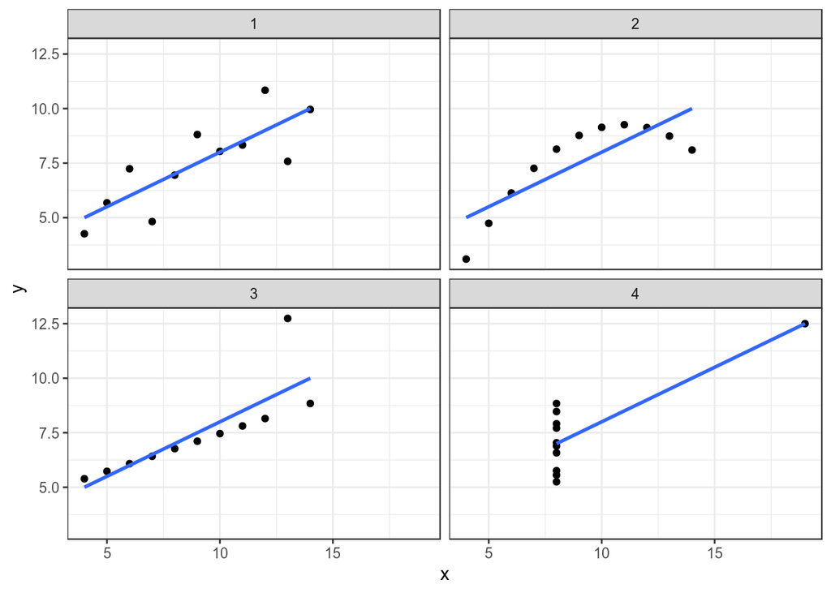

#### 6.0.2 Datasaurus

In [Matejka and Fitzmaurice (2017) “Same Stats, Different Graphs”](https://www.autodeskresearch.com/sites/default/files/SameStats-DifferentGraphs.pdf) was presented the next sets of data:

```r
datasaurus <- read_tsv("https://raw.githubusercontent.com/LingData2019/LingData/master/data/datasaurus.tsv")
head(datasaurus)
```

| dataset | x | y |
| --- | --- | --- |
| dino | 55.3846 | 97.1795 |
| dino | 51.5385 | 96.0256 |
| dino | 46.1538 | 94.4872 |
| dino | 42.8205 | 91.4103 |
| dino | 40.7692 | 88.3333 |
| dino | 38.7179 | 84.8718 |

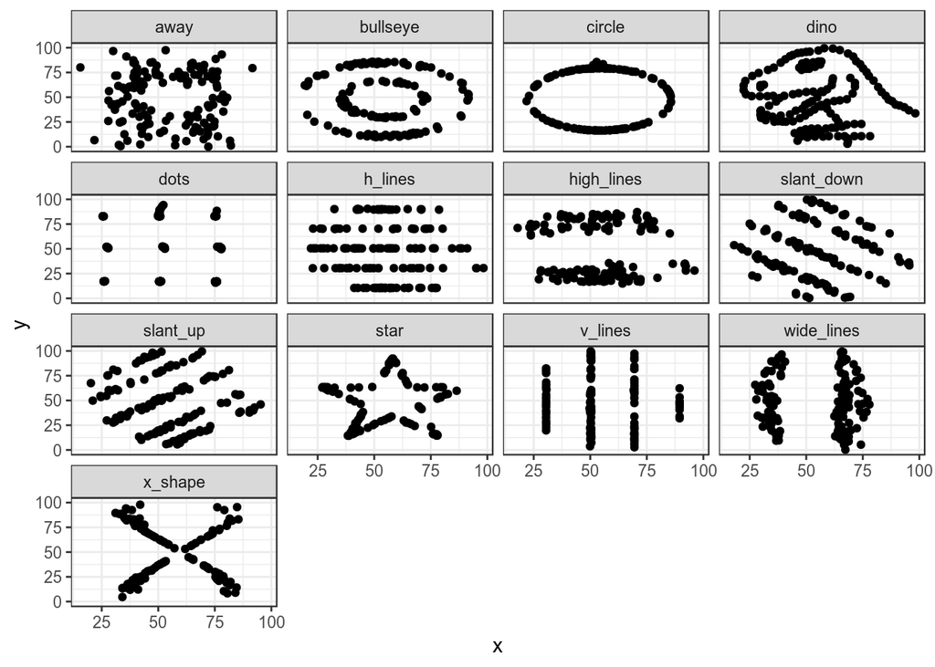

```r
datasaurus %>%
  group_by(dataset) %>%
  summarise(mean_X = mean(x),
            mean_Y = mean(y),
            sd_X = sd(x),
            sd_Y = sd(y),
            cor = cor(x, y),
            n_obs = n()) %>%
  select(-dataset) %>%
  round(., 1)
```

| mean_X | mean_Y | sd_X | sd_Y | cor | n_obs |
| --- | --- | --- | --- | --- | --- |
| 54.3 | 47.8 | 16.8 | 26.9 | -0.1 | 142 |
| 54.3 | 47.8 | 16.8 | 26.9 | -0.1 | 142 |
| 54.3 | 47.8 | 16.8 | 26.9 | -0.1 | 142 |
| 54.3 | 47.8 | 16.8 | 26.9 | -0.1 | 142 |
| 54.3 | 47.8 | 16.8 | 26.9 | -0.1 | 142 |
| 54.3 | 47.8 | 16.8 | 26.9 | -0.1 | 142 |
| 54.3 | 47.8 | 16.8 | 26.9 | -0.1 | 142 |
| 54.3 | 47.8 | 16.8 | 26.9 | -0.1 | 142 |
| 54.3 | 47.8 | 16.8 | 26.9 | -0.1 | 142 |
| 54.3 | 47.8 | 16.8 | 26.9 | -0.1 | 142 |

[output cut: 3 more lines]

#### 6.1 Scaterplot

- ggplot2

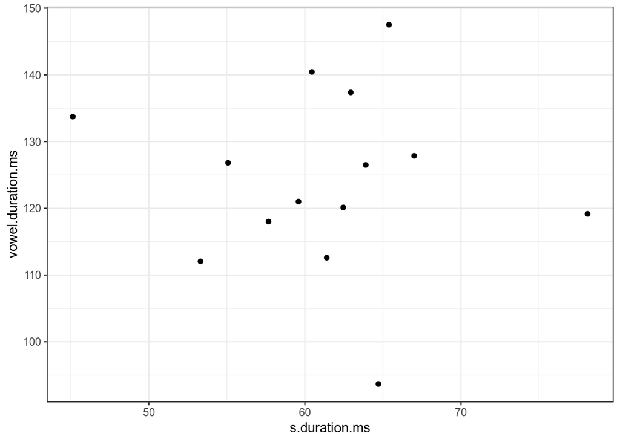

```r
ggplot(data = homo, aes(s.duration.ms, vowel.duration.ms)) +
  geom_point()
```

- dplyr, ggplot2

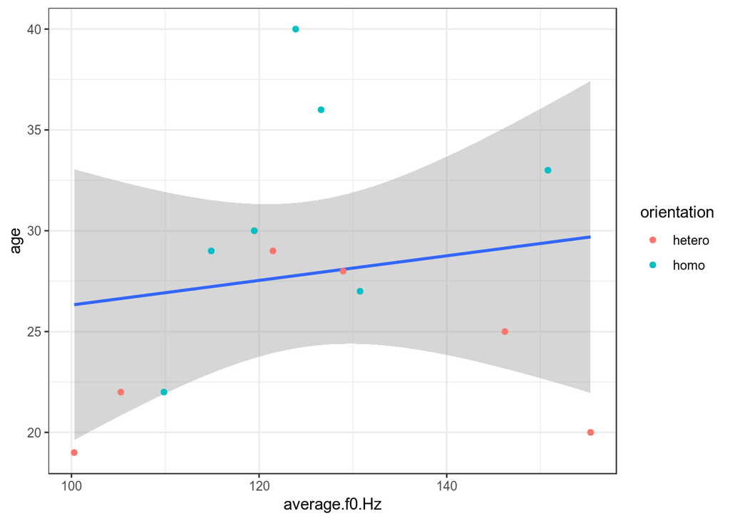

```r
homo %>%
  ggplot(aes(average.f0.Hz, age))+
  geom_smooth(method = "lm")+
  geom_point(aes(color = orientation))
```

##### 6.1.1 Scaterplot: color

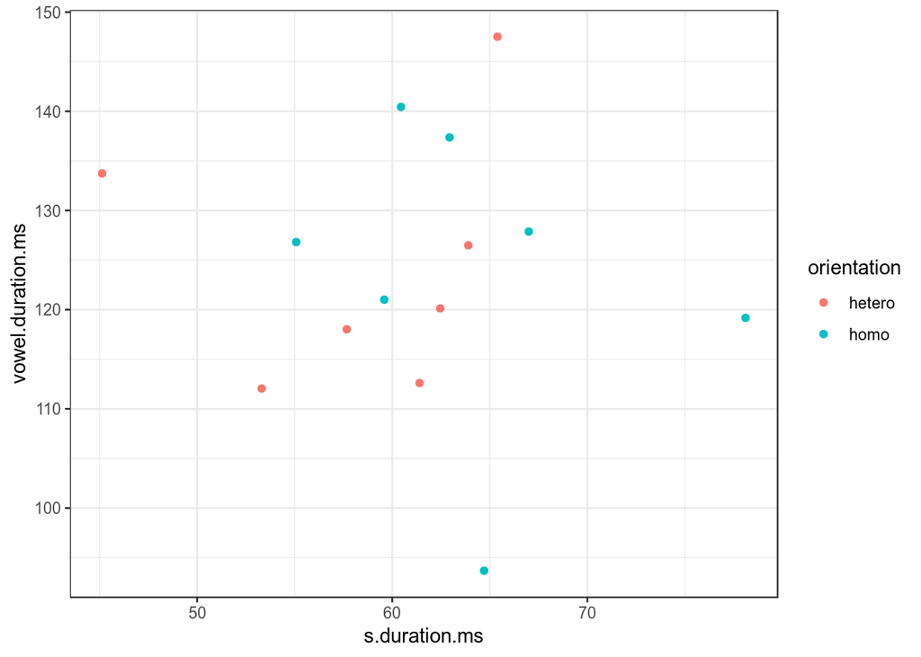

```r
homo %>%
  ggplot(aes(s.duration.ms, vowel.duration.ms,
             color = orientation)) +
  geom_point()
```

##### 6.1.2 Scaterplot: shape

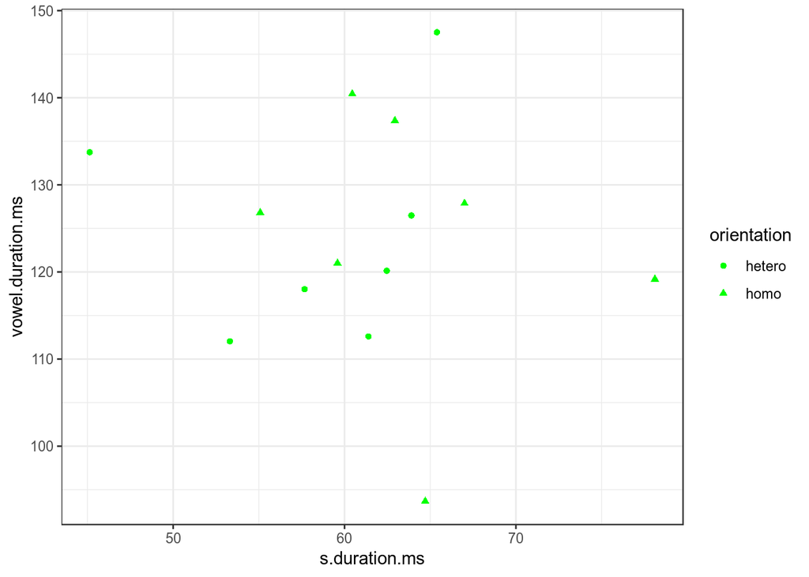

```r
homo %>%
  ggplot(aes(s.duration.ms, vowel.duration.ms,
             shape = orientation)) +
  geom_point(color = "green")
```

##### 6.1.3 Scaterplot: size

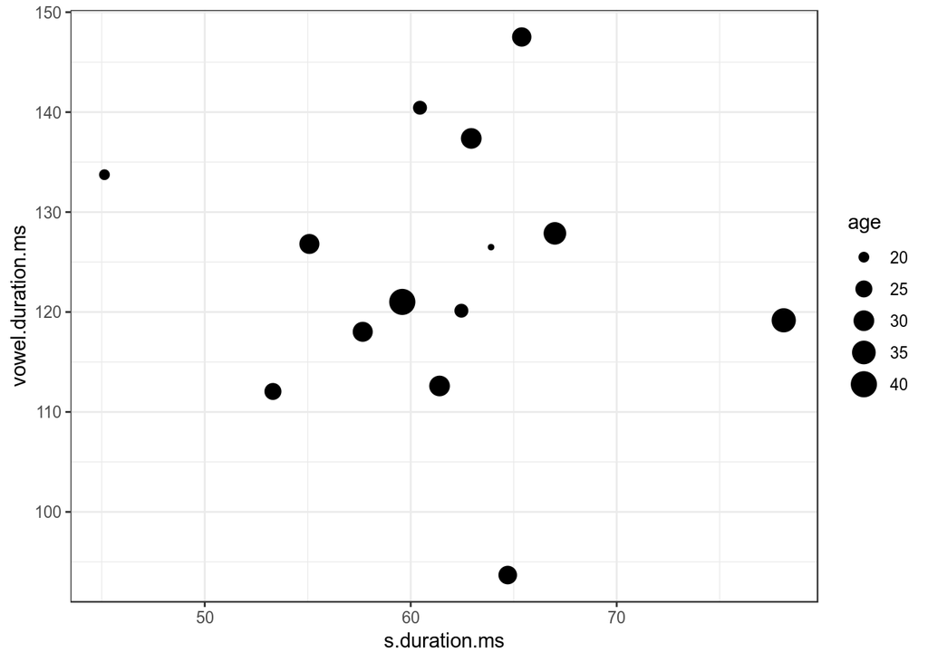

```r
homo %>%
  ggplot(aes(s.duration.ms, vowel.duration.ms,
             size = age)) +
  geom_point()
```

##### 6.1.4 Scaterplot: text

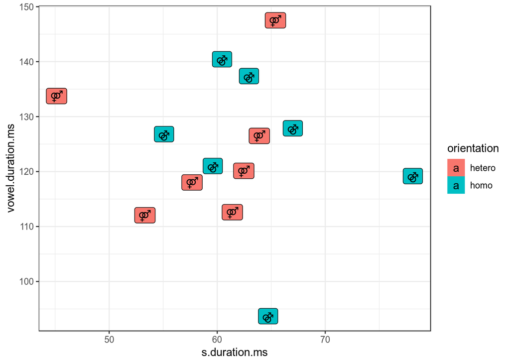

```r
homo %>%
  mutate(label = ifelse(orientation == "homo","⚣", "⚤")) %>%
  ggplot(aes(s.duration.ms, vowel.duration.ms, label = label, fill = orientation)) +
  geom_label()
```

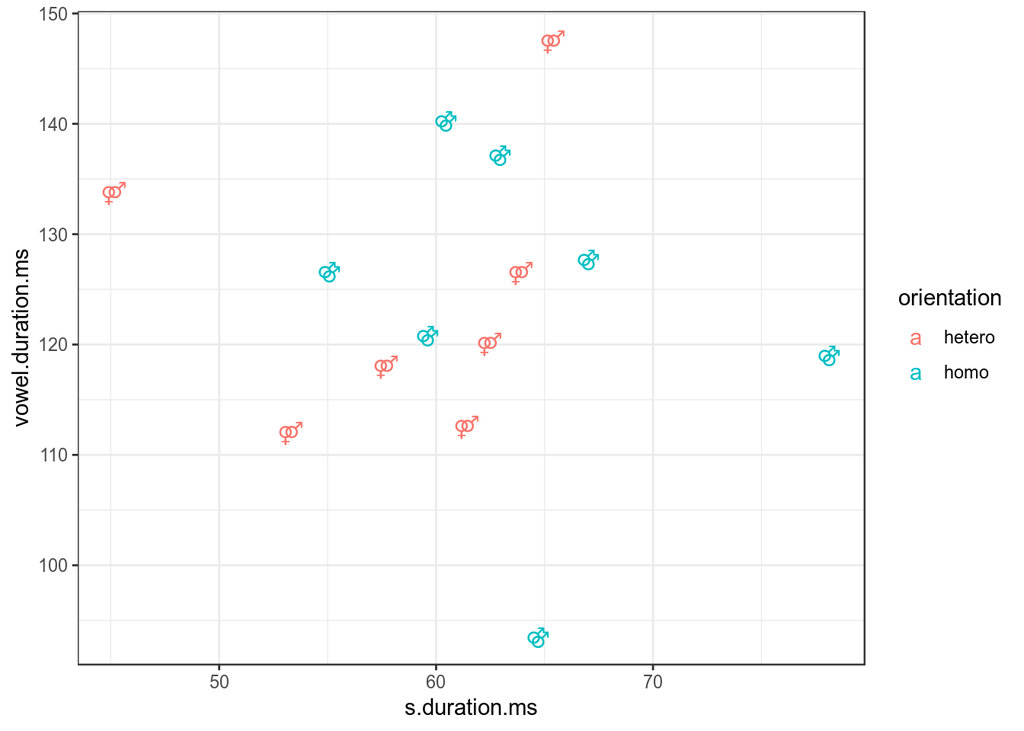

```r
homo %>%
  mutate(label = ifelse(orientation == "homo","⚣", "⚤")) %>%
  ggplot(aes(s.duration.ms, vowel.duration.ms, label = label, color = orientation)) +
  geom_text()
```

##### 6.1.5 Scaterplot: title

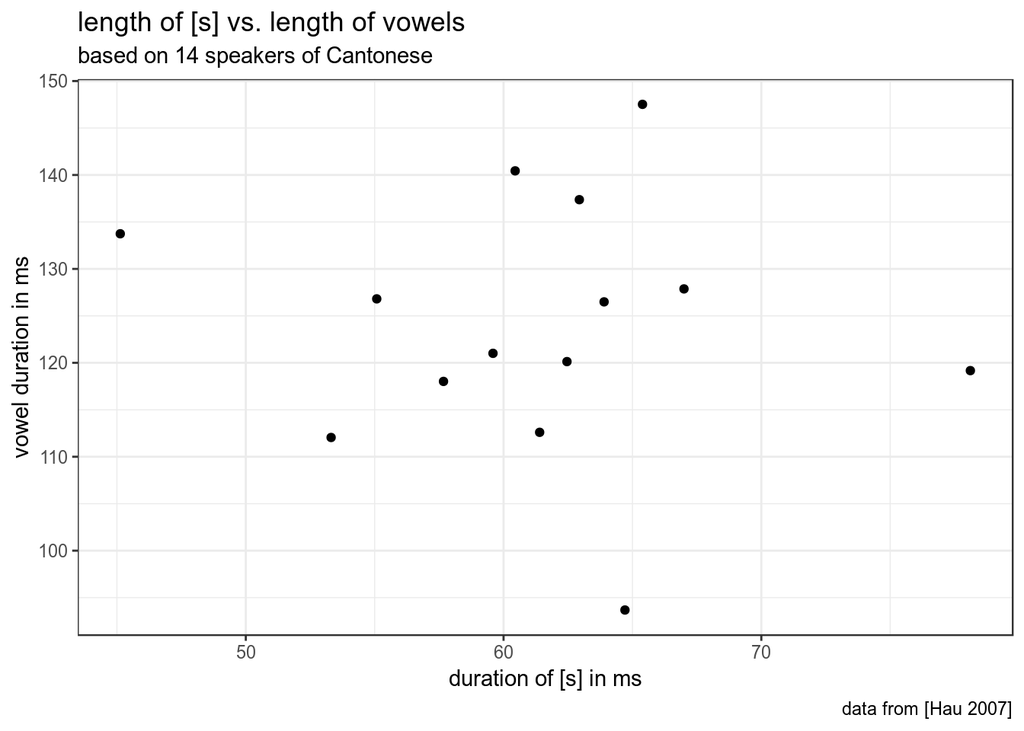

```r
homo %>%
  ggplot(aes(s.duration.ms, vowel.duration.ms)) +
  geom_point()+
  labs(title = "length of [s] vs. length of vowels",
       subtitle = "based on 14 speakers of Cantonese",
       caption = "data from [Hau 2007]",
       x = "duration of [s] in ms",
       y = "vowel duration in ms")
```